# Midterm Project: Sleep Duration and Depressive Symptom Severity in U.S. Adults: An Analysis of NHANES 2017–2018

Author

Faith Okaalo

Published

March 5, 2026

### Step 1: Load the required packages

```r
library(tidyverse)
library(knitr)
library(kableExtra)
library(ggplot2)
library(scales)
library(patchwork)
```

### Introduction

Sleep is a basic need for normal body and brain functioning. It plays a significant role in both physical and mental health. When we sleep, the brain performs vital processes, such as memory processing, hormonal regulation, and tissue and cellular repair (Cassidy et al., 2025). Lack of adequate sleep or excessive sleep is harmful to human health and has been linked to various diseases, such as hypertension, stroke, type 2 diabetes, and mental health disorders, such as anxiety (Fan et al., 2022). According to the Centers for Disease Control and Prevention (CDC), approximately 83.6 million adults in the United States do not get the recommended 7 hours of sleep per night, which underscores this significant public health issue (Centers for Disease Control and Prevention, 2020).

Depression is a common and one of the most prevalent mental health disorders globally, and a leading cause of disability (Dong et al., 2022). In the US, approximately 21 million adults report a major depressive disorder. Depression often co-occurs with sleep disruptions, yet the nature of this relationship is still not fully understood. Some studies have reported poor sleep as a risk factor for depression (Hirshkowitz et al., 2023), while others have identified depression as a cause of sleep disruptions, which highlights their complex relationship (Hamilton et al., 2023).

The National Health and Nutrition Examination Survey (NHANES) is a nationally representative survey conducted by the CDC(Centers for Disease Control and Prevention, 2020). The survey contains information on various health issues, including mental health, lab biomarkers (e.g., BMI), and health behaviors (e.g., smoking, sleep, physical activity, and nutrition). For my midterm project, I used the 2017–2018 questionnaire and demographic files to examine the relationship between sleep duration and depressive symptoms among adults. The 2017–2018 cycle has rich data on sleep behaviors and mental health that were collected using validated self-report instruments, making it ideal for understanding this relationship.

Research Question: Is sleep duration associated with depression among U.S. adults after accounting for demographic covariates?

My hypothesis is that both short (less than 7 hours) and long (more than 9 hours) sleep durations will be associated with higher depression scores than the recommended sleep duration (7-9 hours).

### Step 2: Data Preparation

#### 2.1 Data Source and Acquisition

I obtained and used three publicly available NHANES 2017–2018 datasets for this project.

- **SLQ_J** – Sleep Disorders Questionnaire
- **DPQ_J** – Mental Health Depression Screener (PHQ-9)
- **DEMO_J** – Demographic Variables and Sample Weights

Each participant in the NHANES survey had a unique ID (SEQN), which I used to merge the three downloaded datasets.

```r
# Read in the merged dataset
df_raw <- read.csv("C:/Users/faith/OneDrive/Documents/nhanes_sleep_mental_health.csv", stringsAsFactors = FALSE)
```

### Step 3: Variable selection

Below is a list of the key variables that I selected for this analysis. My exposure of interest is sleep duration and outcome is depression. The covariates that I am including in my analysis include sex, age, race/ethinicity, education and poverty-income ratio, which was informed by existing literature.

| Variable | NHANES Code | Description |
| --- | --- | --- |
| Sleep duration (weekday) | `SLD012` | Hours of sleep on weekdays/workdays |
| Sleep duration (weekend) | `SLD013` | Hours of sleep on weekends |
| PHQ-9 total score | `DPQ010`–`DPQ090` | Nine depression symptom items (computed) |
| Age | `RIDAGEYR` | Age in years |
| Sex | `RIAGENDR` | Biological sex |
| Race/Ethnicity | `RIDRETH3` | Race and Hispanic origin |
| Education | `DMDEDUC2` | Education level (adults 20+) |
| Poverty-income ratio | `INDFMPIR` | Ratio of family income to poverty threshold |

### Step 4: Data wrangling

I did data wrangling in several steps. First, I created a scoring key and converted the PHQ-9 depression items from their original labels into numeric values (“Not at all” coded 0, “Several days” coded 1, “More than half the days” coded 2, and “Nearly every day” coded 3). I then renamed the variables (participant identifier, sleep duration variables, the nine PHQ-9 depression items, age, sex, race/ethnicity, education level, and the poverty-income ratio) that I will be using for this analysis for clarity.

I recoded the nine PHQ-9 items from text to their corresponding numeric scores using the scoring key, and calculated a total PHQ-9 score for each participant by adding the nine items. Respondents who had any missing responses across the nine items were assigned a missing total score and excluded from the analysis.

My exposure of interest is sleep duration, I operationalized it as the average hours of sleep self-reported during the weekend and weekday, which I think gives a more representative estimate of sleep habits that neither measure would alone. I then used the National Sleep Foundation Guidelines (Hirshkowitz et al., 2015 )to categorize participants into three groups as short sleepers (less than 7 hours), normal sleepers (7 to 9 hours), and long sleepers (more than 9 hours).

I simplified the demographic variables and recoded them into meaningful categories. I collapsed the race and ethnicity variable into five groups (Hispanic, Non-Hispanic White, Non-Hispanic Black, Non-Hispanic Asian, and Other/Multiracial). I grouped the education variable into four ordinal levels from less than high school to college graduate and above, and treated this variable as an ordered factor in my subsequent analysis.

I restricted my analytic sample to adults aged 18 years and older. I then excluded observations with missing values for either sleep duration or PHQ-9 total score. I also excluded observations with biologically implausible sleep values (fewer than 2 or more than 18 hours per night), as I considered them extreme outliers or possibly due to data entry errors and may not reflect tru sleep patterns.

```r
# PHQ-9 item scoring map
phq_map <- c(
  "Not at all" = 0,
  "Several days" = 1,
  "More than half the days" = 2,
  "Nearly every day" = 3
)

# Select and recode variables
df <- df_raw %>%
  select(
    SEQN,
    sleep_wkday = SLD012,
    sleep_wkend = SLD013,
    DPQ010, DPQ020, DPQ030, DPQ040,
    DPQ050, DPQ060, DPQ070, DPQ080, DPQ090,
    age     = RIDAGEYR,
    sex     = RIAGENDR,
    race    = RIDRETH3,
    educ    = DMDEDUC2,
    pir     = INDFMPIR
  ) %>%
  # Recode PHQ-9 items
  mutate(across(DPQ010:DPQ090, ~ phq_map[.x])) %>%
  # Compute PHQ-9 total score
  mutate(
    phq9 = rowSums(across(DPQ010:DPQ090), na.rm = FALSE)
  ) %>%
  # Average sleep across weekday and weekend
  mutate(
    sleep_avg = (sleep_wkday + sleep_wkend) / 2
  ) %>%
  # Create sleep category variable
  mutate(
    sleep_cat = case_when(
      sleep_avg < 7  ~ "Short (<7 hrs)",
      sleep_avg <= 9 ~ "Normal (7–9 hrs)",
      sleep_avg > 9  ~ "Long (>9 hrs)"
    ),
    sleep_cat = factor(sleep_cat,
                       levels = c("Short (<7 hrs)",
                                  "Normal (7–9 hrs)",
                                  "Long (>9 hrs)"))
  ) %>%
  # Recode demographics
  mutate(
    sex  = recode(sex,
                  "Male"   = "Male",
                  "Female" = "Female"),
    race = case_when(
      str_detect(race, "Non-Hispanic White")              ~ "Non-Hispanic White",
      str_detect(race, "Non-Hispanic Black")              ~ "Non-Hispanic Black",
      str_detect(race, "Non-Hispanic Asian")              ~ "Non-Hispanic Asian",
      str_detect(race, "Mexican American|Other Hispanic") ~ "Hispanic",
      TRUE                                                ~ "Other/Multiracial"
    ),
    educ = case_when(
      str_detect(educ, "Less than 9th|9-11th") ~ "< High School",
      str_detect(educ, "high school|GED")      ~ "High School/GED",
      str_detect(educ, "Some college|AA")      ~ "Some College",
      str_detect(educ, "College graduate")     ~ "College Graduate+",
      TRUE ~ NA_character_
    ),
    educ = factor(educ,
                  levels = c("< High School", "High School/GED",
                             "Some College", "College Graduate+"))
  ) %>%
  # Restrict to adults 18+ with complete key variables
  filter(
    age >= 18,
    !is.na(phq9),
    !is.na(sleep_avg),
    sleep_avg >= 2 & sleep_avg <= 18  # remove implausible values
  )
```

**My analytic sample**

```r
n_raw    <- nrow(df_raw)
n_adults <- df_raw %>% filter(RIDAGEYR >= 18) %>% nrow()
n_final  <- nrow(df)
```

The raw merged dataset contained **5533** participants across all ages. After restricting to adults aged 18 and older and excluding records with missing values on sleep duration or PHQ-9 items, the final analytic sample included **5015** participants.

### Step 5: Exploratory analysis

#### 5.1 Sample characteristics

The analytic sample included 5015 adults from the NHANES 2017-2018 cycle. The mean age of the participants was 49.5 years (SD =18.5). The average sleep duration reported was 7.9 hours per night (SD =1.5). The average sleep duration reported was 7.9 hours per night (SD=1.5), while the mean PHQ-9 depressive symptom score measured was 3.2 (SD = 4.2). Overall, 8.9% of the participants had moderate to severe depressive symptoms with PHQ-9 scores of 10 or higher. These findings suggest that even though the average sleep duration for this sample is close to the recommended range for adults, a significant proportion of the respondents experienced depressive symptoms.

```r
# Summary table of sample characteristics
tbl1 <- df %>%
  summarise(
    `N` = as.character(n()),
    `Age, mean (SD)` = sprintf("%.1f (%.1f)", mean(age, na.rm=TRUE), sd(age, na.rm=TRUE)),
    `Sleep (avg hrs), mean (SD)` = sprintf("%.1f (%.1f)", mean(sleep_avg, na.rm=TRUE), sd(sleep_avg, na.rm=TRUE)),
    `PHQ-9 score, mean (SD)` = sprintf("%.1f (%.1f)", mean(phq9, na.rm=TRUE), sd(phq9, na.rm=TRUE)),
    `PHQ-9 ≥ 10 (moderate+ depression), n (%)` = sprintf("%d (%.1f%%)",
      sum(phq9 >= 10, na.rm=TRUE),
      100 * mean(phq9 >= 10, na.rm=TRUE))
  ) %>%
  pivot_longer(everything(), names_to = "Characteristic", values_to = "Value")

kable(tbl1,
      caption = "Table 1. Overall Sample Characteristics (NHANES 2017–2018, Adults ≥18)",
      align = c("l","c")) %>%
  kable_styling(bootstrap_options = c("striped","hover","condensed"),
                full_width = FALSE, position = "left")
```

Table 1. Overall Sample Characteristics (NHANES 2017–2018, Adults ≥18)

| Characteristic | Value |
| --- | --- |
| N | 5015 |
| Age, mean (SD) | 49.5 (18.5) |
| Sleep (avg hrs), mean (SD) | 7.9 (1.5) |
| PHQ-9 score, mean (SD) | 3.2 (4.2) |
| PHQ-9 ≥ 10 (moderate+ depression), n (%) | 448 (8.9%) |

```r
# Characteristics by sleep category
tbl2 <- df %>%
  group_by(sleep_cat) %>%
  summarise(
    N = n(),
    `Age, mean (SD)`   = sprintf("%.1f (%.1f)", mean(age, na.rm=TRUE), sd(age, na.rm=TRUE)),
    `% Female`         = sprintf("%.1f%%", 100*mean(sex=="Female", na.rm=TRUE)),
    `% Male`           = sprintf("%.1f%%", 100*mean(sex=="Male", na.rm=TRUE)),
    `PIR, mean (SD)`   = sprintf("%.2f (%.2f)", mean(pir, na.rm=TRUE), sd(pir, na.rm=TRUE)),
    `PHQ-9, mean (SD)` = sprintf("%.1f (%.1f)", mean(phq9, na.rm=TRUE), sd(phq9, na.rm=TRUE))
  ) %>%
  rename(`Sleep Category` = sleep_cat)

kable(tbl2,
      caption = "Table 2. Sample Characteristics by Sleep Duration Category",
      align = c("l","c","c","c","c","c","c","c")) %>%
  kable_styling(bootstrap_options = c("striped","hover","condensed"),
                full_width = FALSE, position = "left")
```

Table 2. Sample Characteristics by Sleep Duration Category

| Sleep Category | N | Age, mean (SD) | % Female | % Male | PIR, mean (SD) | PHQ-9, mean (SD) |
| --- | --- | --- | --- | --- | --- | --- |
| Short (<7 hrs) | 940 | 51.4 (16.8) | 44.8% | 55.2% | 2.46 (1.60) | 3.8 (4.7) |
| Normal (7–9 hrs) | 3267 | 49.6 (18.3) | 51.3% | 48.7% | 2.69 (1.63) | 2.9 (3.9) |
| Long (>9 hrs) | 808 | 47.3 (20.9) | 58.5% | 41.5% | 2.09 (1.48) | 3.7 (4.6) |

Table 2 provides characteristics of the sample population stratified by sleep duration. Sleep duration varied across participants, with the majority (65.1%) reporting normal sleep (7-9 hours), 18.7% reporting short sleep duration (less than 7 hours), and 16.1% reporting long sleep (more than 9 hours). Participants who reported short sleep duration had the highest mean PHQ-9 depression score (3.8, SD = 4.7), followed by those who reported long sleep duration (3.7, SD = 4.6), and those who reported normal sleep duration had the lowest depression score (2.9, SD = 3.9). These findings indicate that short and long sleep duration may be associated with higher depression scores than the recommended sleep duration (7-9 hours). Participants who reported short sleep duration were slightly older on average (51.4 years) compared to those with normal sleep (49.6%) and those with long sleep duration (47.3 years). Participants with normal sleep duration had the highest average poverty-income ratio (PIR) (2.69, SD = 1.63), while those with long slep had the lowest PIR (2.09, SD =1.48) suggesting differences in socio-economic status across the sleep categories. The gender distribution was different across the sleep duration categories. The short sleep duration group had a higher proportion of males (55.2%), while the long sleep duration group had the highest proportion of females (58.5%).

**Covariate summary table**

The sample was demographically diverse, as illustrated in Table 3 below, which summarizes the distribution of all covariates that I included in the adjusted regression model. The sample was relatively balanced in terms of gender, with 51.2% females and 48.8% males. The majority of the participants identified as Non-Hispanic white (35.4%), followed by Non-Hispanic Black (23.1%), Hispanic (22.9%), and Non-Hispanic Asian (13.4%) and a small proportion identified as other or multiracial (5.3%). Most participants (32.8%) had some college education, 24.5% had completed a college degree or higher, 24.1% had completed high school/GED, and 18.6% had less than a high school education. Socioeconomic status had a mean of 2.55 (SD = 1.61) based on 4401 observations.

```r
# Sex distribution
sex_tbl <- df %>%
  filter(!is.na(sex)) %>%
  count(sex) %>%
  mutate(pct = sprintf("%d (%.1f%%)", n, 100 * n / sum(n))) %>%
  select(Category = sex, `n (%)` = pct) %>%
  mutate(Variable = c("Sex", rep("", n() - 1)))

# Race distribution
race_tbl <- df %>%
  filter(!is.na(race)) %>%
  count(race) %>%
  arrange(desc(n)) %>%
  mutate(pct = sprintf("%d (%.1f%%)", n, 100 * n / sum(n))) %>%
  select(Category = race, `n (%)` = pct) %>%
  mutate(Variable = c("Race/Ethnicity", rep("", n() - 1)))

# Education distribution
educ_tbl <- df %>%
  filter(!is.na(educ)) %>%
  count(educ) %>%
  mutate(pct = sprintf("%d (%.1f%%)", n, 100 * n / sum(n))) %>%
  select(Category = educ, `n (%)` = pct) %>%
  mutate(Variable = c("Education", rep("", n() - 1)))

# PIR summary
pir_tbl <- df %>%
  filter(!is.na(pir)) %>%
  summarise(
    Variable = "Poverty-Income Ratio",
    Category = sprintf("Mean (SD): %.2f (%.2f)", mean(pir), sd(pir)),
    `n (%)` = sprintf("n = %d", n())
  )

# Bind all
cov_tbl <- bind_rows(sex_tbl, race_tbl, educ_tbl, pir_tbl) %>%
  select(Variable, Category, `n (%)`)

kable(cov_tbl,
      caption = "Table 3. Distribution of Demographic Covariates in the Analytic Sample",
      align = c("l","l","c")) %>%
  kable_styling(bootstrap_options = c("striped","hover","condensed"),
                full_width = FALSE, position = "left") %>%
  column_spec(1, bold = TRUE)
```

Table 3. Distribution of Demographic Covariates in the Analytic Sample

| Variable | Category | n (%) |
| --- | --- | --- |
| Sex | Female | 2569 (51.2%) |
|  | Male | 2446 (48.8%) |
| Race/Ethnicity | Non-Hispanic White | 1775 (35.4%) |
|  | Non-Hispanic Black | 1158 (23.1%) |
|  | Hispanic | 1146 (22.9%) |
|  | Non-Hispanic Asian | 671 (13.4%) |
|  | Other/Multiracial | 265 (5.3%) |
| Education | < High School | 886 (18.6%) |
|  | High School/GED | 1148 (24.1%) |
|  | Some College | 1562 (32.8%) |
|  | College Graduate+ | 1170 (24.5%) |
| Poverty-Income Ratio | Mean (SD): 2.55 (1.61) | n = 4401 |

#### 5.2 Distribution of key variables

Figures A and C show the distribution of sleep duration in the analytic sample. The histogram shows that most participants reported the recommended and normal sleep duration (between 7 and 9 hours a night). The distribution was approximately symmetrical and centered around 8 hours meaning most participants fell within the normal sleep range, similar to what the bar graph shows, with a few individuals having short or long sleep durations.

Figures B and D show the distribution of PHQ-9 depression scores in the analytic sample. The histogram shows a right-skewed distribution, indicating that the majority of the participants had low depressive symptoms. Most of the PHQ-9 scores ranged between 0 to 3, suggesting minimal depressive symptoms for most participants. The dashed vertical line at PHQ-9 score of 10 shows a threshold for moderate depression. The severity distribution graph also shows that a small proportion of the participants fell above this threshold with many reporting minimal or mild depression and only a few reporting moderate or severe depression.

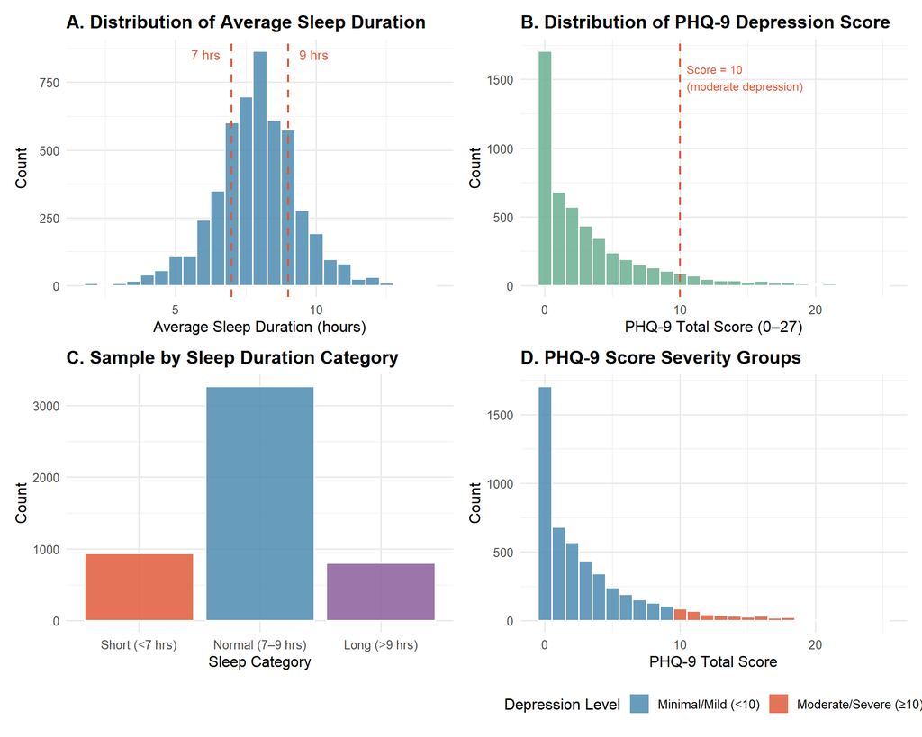

Figure 1: Figure 1. Distributions of sleep duration and PHQ-9 depression scores in the analytic sample.

```r
p1 <- ggplot(df, aes(x = sleep_avg)) +
  geom_histogram(binwidth = 0.5, fill = "#4C8BB0", color = "white", alpha = 0.85) +
  geom_vline(xintercept = c(7, 9), linetype = "dashed", color = "#E05A3A", linewidth = 0.8) +
  annotate("text", x = 6.6, y = Inf, label = "7 hrs", vjust = 2, hjust = 1,
           color = "#E05A3A", size = 3.5) +
  annotate("text", x = 9.4, y = Inf, label = "9 hrs", vjust = 2, hjust = 0,
           color = "#E05A3A", size = 3.5) +
  labs(title = "A. Distribution of Average Sleep Duration",
       x = "Average Sleep Duration (hours)", y = "Count") +
  theme_minimal(base_size = 12) +
  theme(plot.title = element_text(face = "bold"))

p2 <- ggplot(df, aes(x = phq9)) +
  geom_histogram(binwidth = 1, fill = "#6BAF92", color = "white", alpha = 0.85) +
  geom_vline(xintercept = 10, linetype = "dashed", color = "#E05A3A", linewidth = 0.8) +
  annotate("text", x = 10.5, y = Inf, label = "Score = 10\n(moderate depression)",
           vjust = 2, hjust = 0, color = "#E05A3A", size = 3.2) +
  labs(title = "B. Distribution of PHQ-9 Depression Score",
       x = "PHQ-9 Total Score (0–27)", y = "Count") +
  theme_minimal(base_size = 12) +
  theme(plot.title = element_text(face = "bold"))

p3 <- ggplot(df, aes(x = sleep_cat, fill = sleep_cat)) +
  geom_bar(alpha = 0.85, color = "white") +
  scale_fill_manual(values = c("#E05A3A","#4C8BB0","#8B5E9B")) +
  labs(title = "C. Sample by Sleep Duration Category",
       x = "Sleep Category", y = "Count") +
  theme_minimal(base_size = 12) +
  theme(legend.position = "none",
        plot.title = element_text(face = "bold"))

p4 <- ggplot(df, aes(x = phq9, fill = ..x.. > 9)) +
  geom_histogram(binwidth = 1, color = "white", alpha = 0.85) +
  scale_fill_manual(values = c("#4C8BB0","#E05A3A"),
                    labels = c("Minimal/Mild (<10)", "Moderate/Severe (≥10)"),
                    name = "Depression Level") +
  labs(title = "D. PHQ-9 Score Severity Groups",
       x = "PHQ-9 Total Score", y = "Count") +
  theme_minimal(base_size = 12) +
  theme(plot.title = element_text(face = "bold"),
        legend.position = "bottom")

(p1 | p2) / (p3 | p4)
```

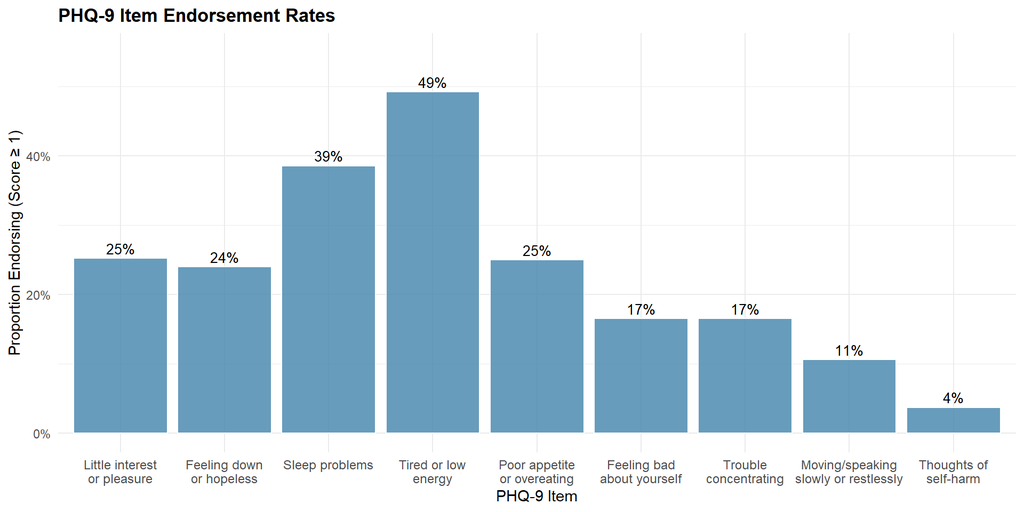

Figure 2: Figure 2. Proportion of respondents endorsing each PHQ-9 depression symptom at any level (score ≥ 1).

```r
phq_labels <- c(
  DPQ010 = "Little interest\nor pleasure",
  DPQ020 = "Feeling down\nor hopeless",
  DPQ030 = "Sleep problems",
  DPQ040 = "Tired or low\nenergy",
  DPQ050 = "Poor appetite\nor overeating",
  DPQ060 = "Feeling bad\nabout yourself",
  DPQ070 = "Trouble\nconcentrating",
  DPQ080 = "Moving/speaking\nslowly or restlessly",
  DPQ090 = "Thoughts of\nself-harm"
)

df %>%
  select(DPQ010:DPQ090) %>%
  pivot_longer(everything(), names_to = "item", values_to = "score") %>%
  filter(!is.na(score)) %>%
  group_by(item) %>%
  summarise(prop_any = mean(score >= 1)) %>%
  mutate(item_label = phq_labels[item],
         item_label = factor(item_label, levels = phq_labels)) %>%
  ggplot(aes(x = item_label, y = prop_any)) +
  geom_col(fill = "#4C8BB0", alpha = 0.85, color = "white") +
  geom_text(aes(label = scales::percent(prop_any, accuracy = 1)),
            vjust = -0.4, size = 3.5) +
  scale_y_continuous(labels = percent_format(), limits = c(0, 0.55)) +
  labs(title = "PHQ-9 Item Endorsement Rates",
       x = "PHQ-9 Item", y = "Proportion Endorsing (Score ≥ 1)") +
  theme_minimal(base_size = 11) +
  theme(axis.text.x = element_text(size = 9),
        plot.title = element_text(face = "bold"))
```

The bar chart above, shows the specific depressive symptoms that were reported by the participants. The most commonly reported depressive symptoms were feeling tired or low energy(49%) and sleep disorders (39%). Other reported symptoms included little interest or pleasure (25%), poor appetite (25%), and feeling down or hopeless (24%). More severe symptoms of depression, such as thoughts of self-harm were rare in this sample (4%).

### Step 6: Preliminary Results

#### 6.1 PHQ-9 Scores by Sleep Duration Category

The boxplot below shows the distribution of PHQ-9 depression scores across sleep duration categories. Participants reporting short sleep (<7 hours) and long sleep (>9 hours) tend to have higher mean depression scores compared with those reporting normal sleep duration (7–9 hours). The interquartile ranges also indicate that depressive symptoms tend to be higher and more variable among individuals with short or long sleep compared with those with normal sleep. The mean PHQ-9 scores, indicated by the diamond markers, are highest for the short sleep group, slightly lower for the long sleep group, and lowest among participants with normal sleep duration. The dots above the boxes are outliers which show that there were some participants with very high depression in all the three groups.

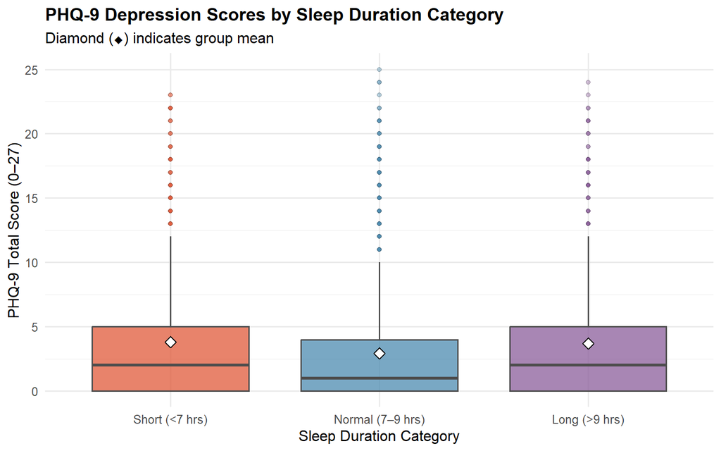

Figure 3: Figure 3. PHQ-9 depression scores by sleep duration category. Boxes show interquartile range; horizontal lines indicate median; points show individual outliers.

```r
ggplot(df, aes(x = sleep_cat, y = phq9, fill = sleep_cat)) +
  geom_boxplot(alpha = 0.75, outlier.shape = 21, outlier.size = 1.5,
               outlier.alpha = 0.4, color = "gray30") +
  stat_summary(fun = mean, geom = "point", shape = 23,
               size = 3, fill = "white", color = "black") +
  scale_fill_manual(values = c("#E05A3A","#4C8BB0","#8B5E9B")) +
  labs(title = "PHQ-9 Depression Scores by Sleep Duration Category",
       subtitle = "Diamond (◆) indicates group mean",
       x = "Sleep Duration Category",
       y = "PHQ-9 Total Score (0–27)") +
  theme_minimal(base_size = 12) +
  theme(legend.position = "none",
        plot.title = element_text(face = "bold"))
```

**Summary statistics**

Table 4 further summarizes depressive symptom levels across sleep categories. Most participants (3,267 out of 5,015) reported normal sleep duration. Participants who reported short sleep duration (< 7 hours) had the highest mean PHQ-9 score (3.82, SD = 4.71) and 11.6% met the threshold for moderate or greater depressive symptoms (PHQ-9 ≥10). Participants who reported long sleep (> 9 hours) also had relatively higher depressive symptoms, with a mean PHQ-9 score of 3.71 (SD = 4.63) and 11.4% meeting the PHQ-9 ≥10 threshold. On the contrary, participants reporting normal sleep duration (7–9 hours) had the lowest depressive symptom levels, with a mean PHQ-9 score of 2.93 (SD = 3.92) and 7.6% meeting the moderate depression threshold.

```r
# Summary stats by sleep category
tbl3 <- df %>%
  group_by(`Sleep Category` = sleep_cat) %>%
  summarise(
    N = n(),
    `Mean PHQ-9` = round(mean(phq9), 2),
    `SD`         = round(sd(phq9), 2),
    `Median`     = median(phq9),
    `IQR`        = sprintf("%.0f–%.0f",
                           quantile(phq9, 0.25),
                           quantile(phq9, 0.75)),
    `% with PHQ-9 ≥ 10` = sprintf("%.1f%%", 100*mean(phq9 >= 10))
  )

kable(tbl3,
      caption = "Table 4. PHQ-9 Scores by Sleep Duration Category",
      align = c("l","c","c","c","c","c","c")) %>%
  kable_styling(bootstrap_options = c("striped","hover","condensed"),
                full_width = FALSE, position = "left")
```

Table 4. PHQ-9 Scores by Sleep Duration Category

| Sleep Category | N | Mean PHQ-9 | SD | Median | IQR | % with PHQ-9 ≥ 10 |
| --- | --- | --- | --- | --- | --- | --- |
| Short (<7 hrs) | 940 | 3.82 | 4.71 | 2 | 0–5 | 11.6% |
| Normal (7–9 hrs) | 3267 | 2.93 | 3.92 | 1 | 0–4 | 7.6% |
| Long (>9 hrs) | 808 | 3.71 | 4.63 | 2 | 0–5 | 11.4% |

#### 6.2 Relationship Between Sleep Duration and PHQ-9 Score

This figure shows the relationship between mean sleep duration and PHQ depression scores. Each point in the graph represents an individual participant, while the red LOESS smoothing curve shows the trend in the data. The shaded vertical region shows the recommended sleep range of 7-9 hours. The plot suggests a U-shaped relationship between sleep duration and depression. PHQ-9 scores tend to be high among individuals with short sleep duration, decline gradually as sleep duration approaches the recommended range, and then begin to rise among those with longer sleep duration. This pattern indicates that excessive and inadequate sleep may be associated with higher PHQ-9 scores, while recommended sleep duration is associated with lower PHQ-9 scores.

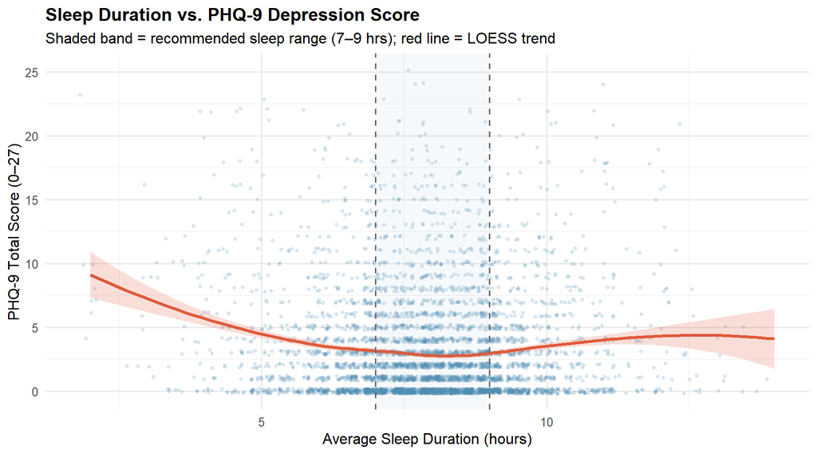

Figure 4: Figure 4. Scatter plot of average sleep duration and PHQ-9 score with LOESS smoothed trend line. Shaded region indicates 95% confidence interval.

```r
ggplot(df, aes(x = sleep_avg, y = phq9)) +
  geom_jitter(alpha = 0.15, width = 0.2, height = 0.2,
              color = "#4C8BB0", size = 0.8) +
  geom_smooth(method = "loess", color = "#E05A3A",
              fill = "#E05A3A", alpha = 0.2, linewidth = 1.2) +
  geom_vline(xintercept = c(7, 9), linetype = "dashed",
             color = "gray40", linewidth = 0.7) +
  annotate("rect", xmin = 7, xmax = 9, ymin = -Inf, ymax = Inf,
           alpha = 0.05, fill = "#4C8BB0") +
  labs(title = "Sleep Duration vs. PHQ-9 Depression Score",
       subtitle = "Shaded band = recommended sleep range (7–9 hrs); red line = LOESS trend",
       x = "Average Sleep Duration (hours)",
       y = "PHQ-9 Total Score (0–27)") +
  theme_minimal(base_size = 12) +
  theme(plot.title = element_text(face = "bold"))
```

#### 6.3 One-Way ANOVA: PHQ-9 across sleep groups

Table 5 presents the results of a one-way ANOVA, which I conducted to examine differences in PHQ-9 scores across the sleep categories. The ANOVA results indicate a statistically significant difference in mean PHQ-9 scores across the sleep categories F (2, 5012) = 22.58, P < 0.001. The ANOVA only tests whether one group differs from the others, so I conducted a TukeyHSD post hoc test to identify which groups differ significantly.

```r
aov_result  <- aov(phq9 ~ sleep_cat, data = df)
aov_summary <- summary(aov_result)[[1]]

kable(aov_summary,
      digits  = 3,
      caption = "Table 5. One-Way ANOVA: PHQ-9 Score by Sleep Duration Category") %>%
  kable_styling(bootstrap_options = c("striped","hover","condensed"),
                full_width = FALSE, position = "left")
```

Table 5. One-Way ANOVA: PHQ-9 Score by Sleep Duration Category

|  | Df | Sum Sq | Mean Sq | F value | Pr(>F) |
| --- | --- | --- | --- | --- | --- |
| sleep_cat | 2 | 796.316 | 398.158 | 22.58 | 0 |
| Residuals | 5012 | 88379.338 | 17.634 | NA | NA |

```r
tukey <- TukeyHSD(aov_result)
tukey_df <- as.data.frame(tukey$sleep_cat) %>%
  rownames_to_column("Comparison") %>%
  rename(`Mean Difference` = diff,
         `Lower 95% CI`   = lwr,
         `Upper 95% CI`   = upr,
         `Adjusted p-value` = `p adj`) %>%
  mutate(across(where(is.numeric), ~ round(.x, 3)))

kable(tukey_df,
      caption = "Table 6. Tukey HSD Post-Hoc Comparisons of PHQ-9 by Sleep Category",
      align   = c("l","c","c","c","c")) %>%
  kable_styling(bootstrap_options = c("striped","hover","condensed"),
                full_width = FALSE, position = "left")
```

Table 6. Tukey HSD Post-Hoc Comparisons of PHQ-9 by Sleep Category

| Comparison | Mean Difference | Lower 95% CI | Upper 95% CI | Adjusted p-value |
| --- | --- | --- | --- | --- |
| Normal (7–9 hrs)-Short (<7 hrs) | -0.885 | -1.249 | -0.521 | 0.000 |
| Long (>9 hrs)-Short (<7 hrs) | -0.112 | -0.584 | 0.361 | 0.845 |
| Long (>9 hrs)-Normal (7–9 hrs) | 0.773 | 0.387 | 1.160 | 0.000 |

Table 6 presents the Tukey HSD post-hoc comparisons between sleep duration categories. Participants with normal sleep duration had significantly lower PHQ-9 scores compared with those reporting short sleep (mean difference = −0.885, 95% CI: −1.249 to −0.521, *p* < 0.001). Similarly, those with long sleep duration had significantly higher PHQ-9 scores than those with normal sleep duration (mean difference = 0.773, 95% CI: 0.387 to 1.160, *p* < 0.001). However, there was no statistically significant difference between the short and long sleep groups (mean difference = −0.112, 95% CI: −0.584 to 0.361, *p* = 0.845).

#### 6.4 PHQ-9 by sex and sleep category

The figure below shows the averagePHQ-9 depression score across sleep duration categories for females and males. A similar pattern is observed in both groups, participants with short sleep duration have the highest PHQ-9 scores, while those with normal sleep duration have the lowest depression scores. Those with long sleep duration have intermediate depression scores. Females reported higher mean PHQ-9 scores than males across all the sleep categories. Despite the differences, the overall pattern across the sleep categories remained similar for both sexes suggesting that the relationship between depression and sleep duration is constistent across males and females.

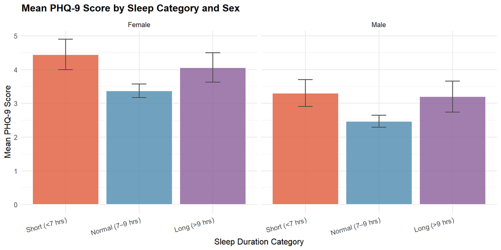

Figure 5: Figure 5. Mean PHQ-9 scores by sleep category, stratified by sex. Error bars represent 95% confidence intervals.

```r
df %>%
  filter(!is.na(sex)) %>%
  group_by(sleep_cat, sex) %>%
  summarise(
    mean_phq = mean(phq9),
    se_phq   = sd(phq9) / sqrt(n()),
    .groups  = "drop"
  ) %>%
  ggplot(aes(x = sleep_cat, y = mean_phq, fill = sleep_cat)) +
  geom_col(alpha = 0.8, color = "white") +
  geom_errorbar(aes(ymin = mean_phq - 1.96*se_phq,
                    ymax = mean_phq + 1.96*se_phq),
                width = 0.2, color = "gray30") +
  facet_wrap(~sex) +
  scale_fill_manual(values = c("#E05A3A","#4C8BB0","#8B5E9B")) +
  labs(title = "Mean PHQ-9 Score by Sleep Category and Sex",
       x = "Sleep Duration Category",
       y = "Mean PHQ-9 Score") +
  theme_minimal(base_size = 12) +
  theme(legend.position = "none",
        plot.title = element_text(face = "bold"),
        axis.text.x = element_text(angle = 15, hjust = 1))
```

#### 6.5 PHQ-9 Scores by education level

The figure shows depression scores across different education levels. Participants with lower levels of education i.e. those with less than high school education had the highest mean depression scores. The mean scores gradually decrease across the education levels with participants who were college graduates or higher reporting the lowest mean PHQ-9 scores. This suggests that higher education attainment is associated with low levels of depression.

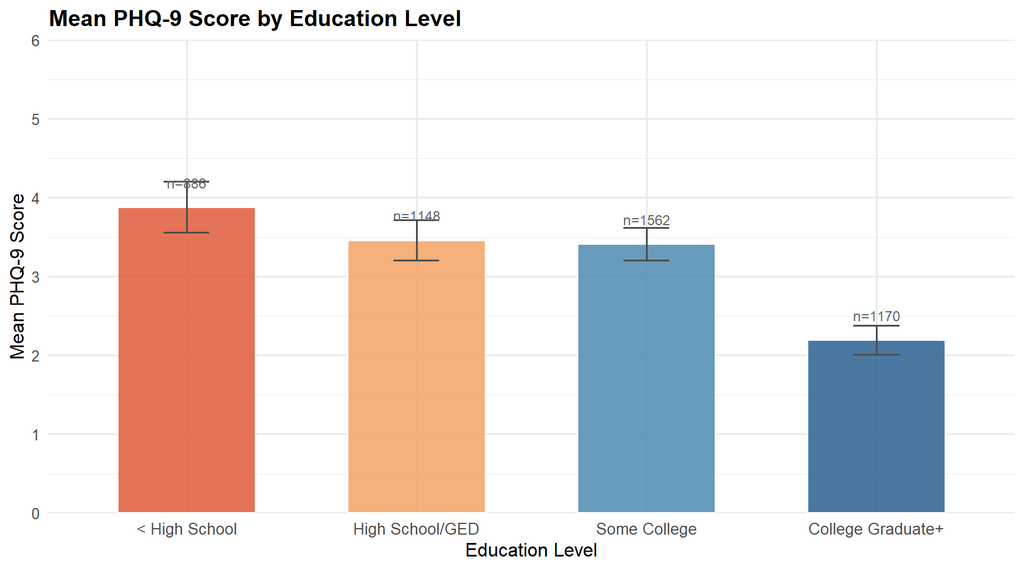

Figure 6: Figure 6. Mean PHQ-9 depression scores by education level. Error bars represent 95% confidence intervals. Higher PHQ-9 scores indicate greater depressive symptom burden.

```r
df %>%
  filter(!is.na(educ)) %>%
  group_by(educ) %>%
  summarise(
    mean_phq = mean(phq9),
    se_phq   = sd(phq9) / sqrt(n()),
    n        = n(),
    .groups  = "drop"
  ) %>%
  ggplot(aes(x = educ, y = mean_phq, fill = educ)) +
  geom_col(alpha = 0.85, color = "white", width = 0.6) +
  geom_errorbar(aes(ymin = mean_phq - 1.96 * se_phq,
                    ymax = mean_phq + 1.96 * se_phq),
                width = 0.2, color = "gray30", linewidth = 0.7) +
  geom_text(aes(label = sprintf("n=%d", n)),
            vjust = -1.8, size = 3.2, color = "gray40") +
  scale_fill_manual(values = c("#E05A3A","#F4A261","#4C8BB0","#2A6090")) +
  scale_y_continuous(limits = c(0, 6), expand = c(0, 0)) +
  labs(title = "Mean PHQ-9 Score by Education Level",
       x = "Education Level",
       y = "Mean PHQ-9 Score") +
  theme_minimal(base_size = 12) +
  theme(legend.position = "none",
        plot.title    = element_text(face = "bold"),
        axis.text.x   = element_text(size = 10))
```

```r
tbl_educ <- df %>%
  filter(!is.na(educ)) %>%
  group_by(`Education Level` = educ) %>%
  summarise(
    N               = n(),
    `Mean PHQ-9`    = round(mean(phq9), 2),
    `SD`            = round(sd(phq9), 2),
    `Median`        = median(phq9),
    `% PHQ-9 ≥ 10` = sprintf("%.1f%%", 100 * mean(phq9 >= 10)),
    `Avg Sleep (hrs)` = round(mean(sleep_avg, na.rm = TRUE), 1)
  )

kable(tbl_educ,
      caption = "Table 8. PHQ-9 Depression Scores and Sleep Duration by Education Level",
      align   = c("l","c","c","c","c","c","c")) %>%
  kable_styling(bootstrap_options = c("striped","hover","condensed"),
                full_width = FALSE, position = "left") %>%
  footnote(general = "PHQ-9 ≥ 10 indicates moderate-to-severe depression.")
```

Table 8. PHQ-9 Depression Scores and Sleep Duration by Education Level

| Education Level | N | Mean PHQ-9 | SD | Median | % PHQ-9 ≥ 10 | Avg Sleep (hrs) |
| --- | --- | --- | --- | --- | --- | --- |
| < High School | 886 | 3.88 | 4.91 | 2 | 12.2% | 8.1 |
| High School/GED | 1148 | 3.46 | 4.44 | 2 | 9.6% | 7.9 |
| Some College | 1562 | 3.41 | 4.16 | 2 | 9.9% | 7.8 |
| College Graduate+ | 1170 | 2.20 | 3.22 | 1 | 4.4% | 7.8 |

Note:  
PHQ-9 ≥ 10 indicates moderate-to-severe depression.

Table 8 provides descriptive statistics on depression scores and sleep duration by education level. Those with less than a high school education had the highest average PHQ-9 score (mean = 3.88, SD = 4.91) and the highest proportion of moderate-to-severe depressive symptoms (12.2%). Participants with a college degree or higher had the lowest mean PHQ-9 score (2.20, SD = 3.22) and the lowest prevalence of moderate-to-severe depression (4.4%). The mean sleep duration was similar across education levels, ranging from 7.8 to 8.1 hours, suggesting that differences in PHQ-9 scores across the education levels are not strongly determined by large differences in sleep duration alone.

#### 6.6 PHQ-9 Scores by Race/Ethnicity

There were variations in PHQ-9 depression scores across racial and ethnic groups, with some of the groups reporting higher scores than others. Multiracial participants had the highest PHQ-9 scores (approximately 4.3), followed by Non-Hispanic White and Hispanic participants who had moderate mean depression scores (approximately 3.3–3.6). Non-Hispanic Black participants had slightly lower mean PHQ-9 scores (approximately 3.0), while Non-Hispanic Asian participants had the lowest average PHQ-9 score (approximately 2.1).

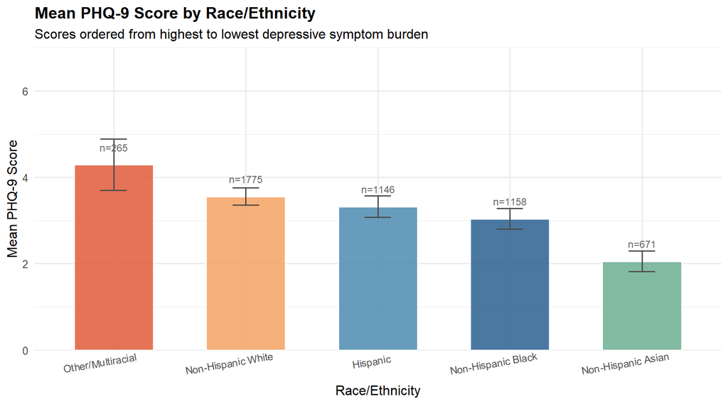

Figure 7: Figure 7. Mean PHQ-9 depression scores by race/ethnicity. Error bars represent 95% confidence intervals.

```r
df %>%
  filter(!is.na(race)) %>%
  group_by(race) %>%
  summarise(
    mean_phq = mean(phq9),
    se_phq   = sd(phq9) / sqrt(n()),
    n        = n(),
    .groups  = "drop"
  ) %>%
  mutate(race = fct_reorder(race, mean_phq, .desc = TRUE)) %>%
  ggplot(aes(x = race, y = mean_phq, fill = race)) +
  geom_col(alpha = 0.85, color = "white", width = 0.6) +
  geom_errorbar(aes(ymin = mean_phq - 1.96 * se_phq,
                    ymax = mean_phq + 1.96 * se_phq),
                width = 0.2, color = "gray30", linewidth = 0.7) +
  geom_text(aes(label = sprintf("n=%d", n)),
            vjust = -1.8, size = 3.2, color = "gray40") +
  scale_fill_manual(values = c("#E05A3A","#F4A261","#4C8BB0",
                               "#2A6090","#6BAF92")) +
  scale_y_continuous(limits = c(0, 7), expand = c(0, 0)) +
  labs(title = "Mean PHQ-9 Score by Race/Ethnicity",
       subtitle = "Scores ordered from highest to lowest depressive symptom burden",
       x = "Race/Ethnicity",
       y = "Mean PHQ-9 Score") +
  theme_minimal(base_size = 12) +
  theme(legend.position = "none",
        plot.title    = element_text(face = "bold"),
        axis.text.x   = element_text(size = 9, angle = 10, hjust = 0.7))
```

#### 6.7 Sleep Duration and PHQ-9 by Race/Ethnicity

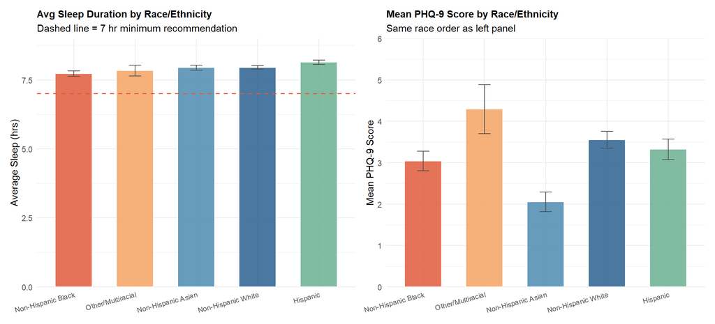

Figure 8: Figure 8. Average sleep duration (left) and mean PHQ-9 score (right) by race/ethnicity, illustrating the joint variation of both key variables across demographic groups.

```r
race_summary <- df %>%
  filter(!is.na(race)) %>%
  group_by(race) %>%
  summarise(
    mean_sleep = mean(sleep_avg, na.rm = TRUE),
    se_sleep   = sd(sleep_avg, na.rm = TRUE) / sqrt(n()),
    mean_phq   = mean(phq9, na.rm = TRUE),
    se_phq     = sd(phq9, na.rm = TRUE) / sqrt(n()),
    .groups    = "drop"
  ) %>%
  mutate(race = fct_reorder(race, mean_sleep))

p_sleep <- ggplot(race_summary, aes(x = race, y = mean_sleep, fill = race)) +
  geom_col(alpha = 0.85, color = "white", width = 0.6) +
  geom_errorbar(aes(ymin = mean_sleep - 1.96 * se_sleep,
                    ymax = mean_sleep + 1.96 * se_sleep),
                width = 0.2, color = "gray30") +
  geom_hline(yintercept = 7, linetype = "dashed",
             color = "#E05A3A", linewidth = 0.7) +
  scale_fill_manual(values = c("#E05A3A","#F4A261","#4C8BB0",
                               "#2A6090","#6BAF92")) +
  scale_y_continuous(limits = c(0, 9), expand = c(0, 0)) +
  labs(title = "Avg Sleep Duration by Race/Ethnicity",
       subtitle = "Dashed line = 7 hr minimum recommendation",
       x = NULL, y = "Average Sleep (hrs)") +
  theme_minimal(base_size = 11) +
  theme(legend.position = "none",
        plot.title  = element_text(face = "bold", size = 11),
        axis.text.x = element_text(angle = 15, hjust = 1, size = 8))

p_phq <- ggplot(race_summary, aes(x = race, y = mean_phq, fill = race)) +
  geom_col(alpha = 0.85, color = "white", width = 0.6) +
  geom_errorbar(aes(ymin = mean_phq - 1.96 * se_phq,
                    ymax = mean_phq + 1.96 * se_phq),
                width = 0.2, color = "gray30") +
  scale_fill_manual(values = c("#E05A3A","#F4A261","#4C8BB0",
                               "#2A6090","#6BAF92")) +
  scale_y_continuous(limits = c(0, 6), expand = c(0, 0)) +
  labs(title = "Mean PHQ-9 Score by Race/Ethnicity",
       subtitle = "Same race order as left panel",
       x = NULL, y = "Mean PHQ-9 Score") +
  theme_minimal(base_size = 11) +
  theme(legend.position = "none",
        plot.title  = element_text(face = "bold", size = 11),
        axis.text.x = element_text(angle = 15, hjust = 1, size = 8))

p_sleep | p_phq
```

The graph on the left shows that average sleep duration was relatively similar across racial groups, and most groups reported sleep duration above the recommended threshold of 7 hours per night, though there were very small differences across the groups. Hispanic participants reported the longest sleep duration, while Non-Hispanic Black participants had the shortest.

```r
tbl_race <- df %>%
  filter(!is.na(race)) %>%
  group_by(`Race/Ethnicity` = race) %>%
  summarise(
    N                 = n(),
    `Avg Sleep (hrs)` = round(mean(sleep_avg, na.rm = TRUE), 1),
    `Mean PHQ-9`      = round(mean(phq9), 2),
    `SD PHQ-9`        = round(sd(phq9), 2),
    `% PHQ-9 ≥ 10`   = sprintf("%.1f%%", 100 * mean(phq9 >= 10)),
    `% Short Sleep`   = sprintf("%.1f%%", 100 * mean(sleep_avg < 7, na.rm = TRUE))
  ) %>%
  arrange(desc(`Mean PHQ-9`))

kable(tbl_race,
      caption = "Table 9. Sleep Duration and PHQ-9 Depression Scores by Race/Ethnicity",
      align   = c("l","c","c","c","c","c","c")) %>%
  kable_styling(bootstrap_options = c("striped","hover","condensed"),
                full_width = FALSE, position = "left") %>%
  footnote(general = "Short sleep defined as average sleep duration < 7 hours per night.")
```

Table 9. Sleep Duration and PHQ-9 Depression Scores by Race/Ethnicity

| Race/Ethnicity | N | Avg Sleep (hrs) | Mean PHQ-9 | SD PHQ-9 | % PHQ-9 ≥ 10 | % Short Sleep |
| --- | --- | --- | --- | --- | --- | --- |
| Other/Multiracial | 265 | 7.8 | 4.29 | 4.91 | 14.3% | 23.0% |
| Non-Hispanic White | 1775 | 7.9 | 3.56 | 4.37 | 10.3% | 16.9% |
| Hispanic | 1146 | 8.1 | 3.32 | 4.33 | 9.5% | 15.2% |
| Non-Hispanic Black | 1158 | 7.7 | 3.04 | 4.10 | 8.1% | 26.6% |
| Non-Hispanic Asian | 671 | 7.9 | 2.06 | 3.13 | 3.7% | 14.5% |

Note:  
Short sleep defined as average sleep duration < 7 hours per night.

Table 9 provides additional descriptive statistics on sleep duration and depression indicators across racial and ethnic groups. Multiracial participants had the highest average PHQ-9 score (mean = 4.29) and the highest proportion of individuals with moderate-to-severe depression PHQ-9 ≥10 (14.3%). Non-Hispanic Asian participants had the lowest mean PHQ-9 score (2.06) and the lowest prevalence of moderate-to-severe depressive symptoms (3.7%). The average sleep duration was similar across groups, indicating that most participants across racial and ethnic groups reported sleep duration within the recommended normal range. The prevalence of short sleep duration varied significantly across groups with Non-Hispanic Black participants having the highest proportion of short sleep (26.6%), followed by Other/Multiracial participants (23.0%), while Non-Hispanic Asian participants had the lowest prevalence of short sleep duration (14.5%). The patterns of sleep duration and depression scores varied across the racial groups highlighting disparities in sleep and mental health.

#### 6.8 Linear regression: Sleep duration predicting PHQ-9

```r
# Simple linear regression
lm_simple <- lm(phq9 ~ sleep_avg, data = df)

# Multiple regression with covariates
lm_multi <- lm(phq9 ~ sleep_avg + age + sex + race + educ + pir, data = df)

# Format regression table
extract_lm <- function(model, label) {
  s <- summary(model)$coefficients
  data.frame(
    Model      = label,
    Term       = rownames(s),
    Estimate   = round(s[,"Estimate"], 3),
    `Std. Error` = round(s[,"Std. Error"], 3),
    `t value`    = round(s[,"t value"], 3),
    `p value`    = ifelse(s[,"Pr(>|t|)"] < 0.001, "<0.001",
                          round(s[,"Pr(>|t|)"], 3))
  )
}

reg_tbl <- bind_rows(
  extract_lm(lm_simple, "Unadjusted"),
  extract_lm(lm_multi,  "Adjusted")
) %>%
  filter(Term == "sleep_avg")

kable(reg_tbl,
      caption = "Table 7. Linear Regression Coefficients for Sleep Duration Predicting PHQ-9 Score",
      row.names = FALSE,
      align = c("l","l","c","c","c","c")) %>%
  kable_styling(bootstrap_options = c("striped","hover","condensed"),
                full_width = FALSE, position = "left") %>%
  footnote(general = "Adjusted model controls for age, sex, race/ethnicity, education, and poverty-income ratio.")
```

Table 7. Linear Regression Coefficients for Sleep Duration Predicting PHQ-9 Score

| Model | Term | Estimate | Std..Error | t.value | p.value |
| --- | --- | --- | --- | --- | --- |
| Unadjusted | sleep_avg | -0.098 | 0.040 | -2.445 | 0.015 |
| Adjusted | sleep_avg | -0.167 | 0.043 | -3.885 | <0.001 |

Note:  
Adjusted model controls for age, sex, race/ethnicity, education, and poverty-income ratio.

### Step 7: Summary of key findings

**Limitations.**

I must acknowledge that this analysis has several limitations. First, causal inference cannot be drawn from this analysis because the NHANES is a cross-sectional survey. Even though sleep duration and depression had a significant association, it is difficult to determine the direction of the relationship from this data alone because depression may disrupt sleep patterns, rather than or also in addition to sleep affecting depression. Longitudinal data is needed to assess the temporal sequence. Second, sleep duration and depression were self-reported, which may be subject to recall bias and not reflect accurate estimates of sleep duration. More accurate measures are needed, such as actigraphy. Though the PHQ-9 is a validated scale for screening for depression, it is not as accurate as a clinical diagnosis of depression and may still misclassify participants because it relies on self-reported symptoms. Third, I used the NHANES 2017-2018 data. I made this decision because the 2019-2020 and subsequent cycles were disrupted by the COVID-19 pandemic, resulting in incomplete data collection. Finally, even though I accounted for demographic covariates in my adjusted model, residual confounding from other variables such as physical activity, chronic illness, medication use, and substance use cannot be ruled out.

### **References**

Cassidy, S., Chau, J. Y., Catt, M., Bauman, A., & Mishra, G. D. (2025). Associations between sleep duration and depression, mental health, physical health, and general health in U.S. adults: A population-based study. *PLOS ONE*. https://doi.org/10.1371/journal.pone.0321347

Centers for Disease Control and Prevention, National Center for Health Statistics. (2020). *National Health and Nutrition Examination Survey: 2017–2018 data documentation.* U.S. Department of Health and Human Services. https://wwwn.cdc.gov/nchs/nhanes/continuousnhanes/default.aspx?BeginYear=2017

Dong, L., Xie, Y., & Zou, X. (2022). Association between sleep duration and depression in US adults: A cross-sectional study. *Journal of Affective Disorders, 296*, 183–188. https://doi.org/10.1016/j.jad.2021.09.075

Fan, Y., Sun, Y., & Zhang, L. (2025). Regular sleep patterns, not just duration, critical for mental health: Association of accelerometer-derived sleep regularity with incident depression and anxiety. *Frontiers in Psychiatry*. https://pmc.ncbi.nlm.nih.gov/articles/PMC12404321/

Hamilton, O. S., Moullet, A., & Steptoe, A. (2023). Polygenic predisposition, sleep duration, and depression: Evidence from a prospective population-based cohort. *Translational Psychiatry, 13*, 327. https://doi.org/10.1038/s41398-023-02622-z

Hirshkowitz, M., Whiton, K., Albert, S. M., Alessi, C., Bruni, O., DonCarlos, L., Hazen, N., Herman, J., Katz, E. S., Kheirandish-Gozal, L., Neubauer, D. N., O’Donnell, A. E., Ohayon, M., Peever, J., Rawding, R., Sachdeva, R. C., Setters, B., Vitiello, M. V., Ware, J. C., & Hillard, P. J. A. (2015). National Sleep Foundation’s updated sleep duration recommendations: Final report. *Sleep Health, 1*(4), 233–243. https://doi.org/10.1016/j.sleh.2015.10.004